```python
import numpy as np
import pandas as pd
import seaborn as sns
import matplotlib.pyplot as plt
import requests

houseDatasetPath = 'D:/Data Mining/CA/1/Datasets/house.csv'
usersDatasetPath = 'D:/Data Mining/CA/1/Datasets/users.csv'
purchaseDatasetPath = 'D:/Data Mining/CA/1/Datasets/purchases.csv'
```

```python
pd.options.display.max_rows = 100
```

# House

## Preprocessing

### 1 : First Five rows

```python
house_df = pd.read_csv(houseDatasetPath)
house_df.head()
```

|  | Id | MSSubClass | MSZoning | LotFrontage | LotArea | Street | Alley | LotShape | LandContour | Utilities | ... | PoolArea | PoolQC | Fence | MiscFeature | MiscVal | MoSold | YrSold | SaleType | SaleCondition | SalePrice |
| --- | --- | --- | --- | --- | --- | --- | --- | --- | --- | --- | --- | --- | --- | --- | --- | --- | --- | --- | --- | --- | --- |
| 0 | 1 | 60 | RL | 65.0 | 8450 | Pave | NaN | Reg | Lvl | AllPub | ... | 0 | NaN | NaN | NaN | 0 | 2 | 2008 | WD | Normal | 208500 |
| 1 | 2 | 20 | RL | 80.0 | 9600 | Pave | NaN | Reg | Lvl | AllPub | ... | 0 | NaN | NaN | NaN | 0 | 5 | 2007 | WD | Normal | 181500 |
| 2 | 3 | 60 | RL | 68.0 | 11250 | Pave | NaN | IR1 | Lvl | AllPub | ... | 0 | NaN | NaN | NaN | 0 | 9 | 2008 | WD | Normal | 223500 |
| 3 | 4 | 70 | RL | 60.0 | 9550 | Pave | NaN | IR1 | Lvl | AllPub | ... | 0 | NaN | NaN | NaN | 0 | 2 | 2006 | WD | Abnorml | 140000 |
| 4 | 5 | 60 | RL | 84.0 | 14260 | Pave | NaN | IR1 | Lvl | AllPub | ... | 0 | NaN | NaN | NaN | 0 | 12 | 2008 | WD | Normal | 250000 |

5 rows × 81 columns

### 2 : Missing Values

```python
house_df.isna().sum().sort_values(ascending=False)
```

```
PoolQC           2909
MiscFeature      2814
Alley            2721
Fence            2348
FireplaceQu      1420
LotFrontage       486
GarageFinish      159
GarageQual        159
GarageCond        159
GarageYrBlt       159
GarageType        157
BsmtExposure       82
BsmtCond           82
BsmtQual           81
BsmtFinType2       80
BsmtFinType1       79
MasVnrType         24
MasVnrArea         23
MSZoning            4
Functional          2
Utilities           2
BsmtHalfBath        2
BsmtFullBath        2
GarageArea          1
BsmtFinSF1          1
SaleType            1
GarageCars          1
BsmtUnfSF           1
Electrical          1
Exterior2nd         1
Exterior1st         1
KitchenQual         1
TotalBsmtSF         1
BsmtFinSF2          1
TotRmsAbvGrd        0
Fireplaces          0
Id                  0
BedroomAbvGr        0
PavedDrive          0
WoodDeckSF          0
```

[output cut: 27 more lines]

```
YearRemodAdd        0
RoofStyle           0
RoofMatl            0
ExterQual           0
ExterCond           0
Foundation          0
Heating             0
MSSubClass          0
CentralAir          0
1stFlrSF            0
2ndFlrSF            0
LowQualFinSF        0
GrLivArea           0
SalePrice           0
dtype: int64
```

### 3,4 : Handle Missing Values

First, we address Nan values in non-numerical columns. According to the data description, the NA values in the features below represent the absence of the feature. For example, the NA values in the PoolQC column mean that the house doesn't have a pool. They are not missing. Therefore, we replace NaN with the constant value None. But, in other situations, we should drop the column if a high percentage of data is missing.

```python
attrs = ["PoolQC","MiscFeature","Alley","Fence",'FireplaceQu',
         'GarageType','GarageQual','GarageCond','GarageFinish',
         'BsmtCond','BsmtExposure','BsmtQual','BsmtFinType2','BsmtFinType1']

house_df[attrs] = house_df[attrs].fillna("None")
```

Then we find columns with a small percentage of missing values. We choose columns where the Nan values in them are less than 0.2%. Then we drop rows accordingly.

```python
cols = np.where((house_df.isna().sum() < 5) & (house_df.isna().sum() > 0))
house_df.dropna(subset = house_df.columns[cols], inplace = True)
house_df
```

|  | Id | MSSubClass | MSZoning | LotFrontage | LotArea | Street | Alley | LotShape | LandContour | Utilities | ... | PoolArea | PoolQC | Fence | MiscFeature | MiscVal | MoSold | YrSold | SaleType | SaleCondition | SalePrice |
| --- | --- | --- | --- | --- | --- | --- | --- | --- | --- | --- | --- | --- | --- | --- | --- | --- | --- | --- | --- | --- | --- |
| 0 | 1 | 60 | RL | 65.0 | 8450 | Pave | None | Reg | Lvl | AllPub | ... | 0 | None | None | None | 0 | 2 | 2008 | WD | Normal | 208500 |
| 1 | 2 | 20 | RL | 80.0 | 9600 | Pave | None | Reg | Lvl | AllPub | ... | 0 | None | None | None | 0 | 5 | 2007 | WD | Normal | 181500 |
| 2 | 3 | 60 | RL | 68.0 | 11250 | Pave | None | IR1 | Lvl | AllPub | ... | 0 | None | None | None | 0 | 9 | 2008 | WD | Normal | 223500 |
| 3 | 4 | 70 | RL | 60.0 | 9550 | Pave | None | IR1 | Lvl | AllPub | ... | 0 | None | None | None | 0 | 2 | 2006 | WD | Abnorml | 140000 |
| 4 | 5 | 60 | RL | 84.0 | 14260 | Pave | None | IR1 | Lvl | AllPub | ... | 0 | None | None | None | 0 | 12 | 2008 | WD | Normal | 250000 |
| ... | ... | ... | ... | ... | ... | ... | ... | ... | ... | ... | ... | ... | ... | ... | ... | ... | ... | ... | ... | ... | ... |
| 2914 | 2915 | 160 | RM | 21.0 | 1936 | Pave | None | Reg | Lvl | AllPub | ... | 0 | None | None | None | 0 | 6 | 2006 | WD | Normal | 177000 |
| 2915 | 2916 | 160 | RM | 21.0 | 1894 | Pave | None | Reg | Lvl | AllPub | ... | 0 | None | None | None | 0 | 4 | 2006 | WD | Abnorml | 181000 |
| 2916 | 2917 | 20 | RL | 160.0 | 20000 | Pave | None | Reg | Lvl | AllPub | ... | 0 | None | None | None | 0 | 9 | 2006 | WD | Abnorml | 176000 |
| 2917 | 2918 | 85 | RL | 62.0 | 10441 | Pave | None | Reg | Lvl | AllPub | ... | 0 | None | MnPrv | Shed | 700 | 7 | 2006 | WD | Normal | 276000 |
| 2918 | 2919 | 60 | RL | 74.0 | 9627 | Pave | None | Reg | Lvl | AllPub | ... | 0 | None | None | None | 0 | 11 | 2006 | WD | Normal | 250000 |

2906 rows × 81 columns

For the rest of the numerical columns, we plot histograms to illustrate the distribution of data. If they have an approximately normal distribution we replace Nan with the average of the column. Otherwise, we use median. For the remaining categorical columns, we replace nan values with mode.

```python
house_numerical = house_df.select_dtypes(exclude = ['object'])
house_numerical.drop(columns='Id' , inplace=True)
columns = np.where(house_numerical.isna().sum() > 0)
columns_with_Nan = house_numerical.columns[columns]
columns_with_Nan
```

```
Index(['LotFrontage', 'MasVnrArea', 'GarageYrBlt'], dtype='object')
```

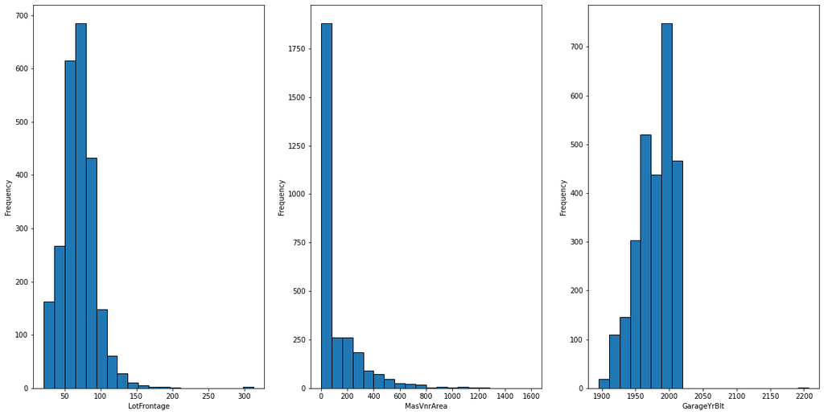

```python
rows , cols = 1 , 3
plt.figure(figsize=(20,10))
for f in range(len(columns_with_Nan)):
    column = columns_with_Nan[f]
    plt.subplot(rows, cols , f + 1)
    plt.xlabel(column,loc='center')
    plt.ylabel("Frequency")
    plt.hist(house_df[column], edgecolor='black', bins=20)

plt.show()
```

```python
house_df['LotFrontage'].fillna(house_df['LotFrontage'].median(),inplace = True)
house_df['GarageYrBlt'].fillna(house_df['GarageYrBlt'].median(),inplace = True)
house_df['MasVnrArea'].fillna(house_df['MasVnrArea'].median(), inplace = True)
house_df['MasVnrType'].fillna(house_df['MasVnrType'].mode()[0], inplace = True)
```

### 5: Outliers

There are various ways to detect outliers and deal with them. For normal distributions, we can use z-score. Data points outside (mean - 3std, mean + 3std) are considered outliers.

Using IQR is another way. We can also use visualisation tools like box plots, histograms, or scatterplots to find outliers.

To deal with outliers, we can delete them or replace them with another value. If I removed outliers in each column, over 25% of the dataset would be removed. So I replaced them.

Here I decided to winsorize data; meaning that I replaced outliers with a specified percentile of the data. (first and 99th)

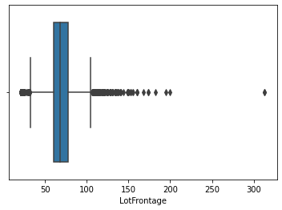

```python
sns.boxplot(x = 'LotFrontage' , data = house_df)
```

```python
new_house_df = house_df.copy()
cols = house_numerical.columns
upper_limit = house_numerical.quantile(0.99)
lower_limit = house_numerical.quantile(0.01)
for v in cols:
    new_house_df[v] = np.where(new_house_df[v] > upper_limit[v], upper_limit[v],
                                np.where(new_house_df[v] < lower_limit[v] , lower_limit[v], new_house_df[v]))
```

## 6

Looking at the scatter plot below, we can easily spot many houses with larger living area and lower sale price.

For example, houses at the top left are more expensive compare to houses at the bottom right of the plot.

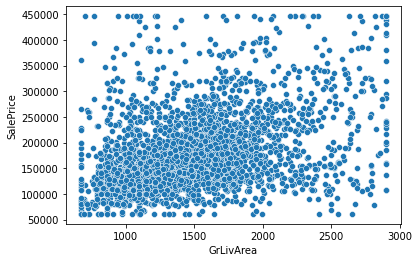

```python
sns.scatterplot(x = new_house_df['GrLivArea'], y = new_house_df["SalePrice"]) # LotArea
```

By applying some constraints on data, we can show these records.

```python
x1 = new_house_df[(new_house_df['GrLivArea'] > 2700) & (new_house_df['SalePrice'] < 80000)]
print(x1)
new_house_df[(new_house_df['GrLivArea'] < 700)  & (new_house_df['SalePrice'] > 200000)]
```

```
        Id  MSSubClass MSZoning  LotFrontage  LotArea Street Alley LotShape  \
2155  2156        60.0       RL         68.0   9771.0   Pave  None      IR3

     LandContour Utilities  ... PoolArea PoolQC  Fence MiscFeature MiscVal  \
2155         Lvl    AllPub  ...      0.0   None  GdPrv        None     0.0

     MoSold  YrSold  SaleType  SaleCondition  SalePrice
2155    6.0  2008.0        WD         Normal    78000.0

[1 rows x 81 columns]
```

|  | Id | MSSubClass | MSZoning | LotFrontage | LotArea | Street | Alley | LotShape | LandContour | Utilities | ... | PoolArea | PoolQC | Fence | MiscFeature | MiscVal | MoSold | YrSold | SaleType | SaleCondition | SalePrice |
| --- | --- | --- | --- | --- | --- | --- | --- | --- | --- | --- | --- | --- | --- | --- | --- | --- | --- | --- | --- | --- | --- |
| 2088 | 2089 | 30.0 | RM | 60.0 | 4800.0 | Pave | None | Reg | Lvl | AllPub | ... | 0.0 | None | MnPrv | None | 0.0 | 8.0 | 2008.0 | WD | Normal | 360000.0 |
| 2098 | 2099 | 20.0 | RM | 62.0 | 7311.0 | Pave | None | Reg | Lvl | AllPub | ... | 0.0 | None | None | None | 0.0 | 3.0 | 2008.0 | WD | Abnorml | 226000.0 |
| 2399 | 2400 | 50.0 | RL | 51.0 | 3500.0 | Pave | None | Reg | Lvl | AllPub | ... | 0.0 | None | MnPrv | Shed | 995.0 | 7.0 | 2007.0 | WD | Normal | 227875.0 |
| 2871 | 2872 | 30.0 | RL | 60.0 | 8088.0 | Pave | Grvl | Reg | Lvl | AllPub | ... | 0.0 | None | None | None | 0.0 | 2.0 | 2006.0 | ConLD | Normal | 264561.0 |
| 2889 | 2890 | 30.0 | RM | 50.0 | 7030.0 | Pave | None | Reg | Lvl | AllPub | ... | 0.0 | None | MnPrv | None | 0.0 | 3.0 | 2006.0 | WD | Normal | 225000.0 |

5 rows × 81 columns

Most of these houses with higher sale price are from MSSubClass 30 which describes a 1-STORY house built in 1945 & OLDER. Maybe the older buildings are more expensive!

Another reason is that maybe data is incorrect and human or computer error happened in gathering data

```python
new_house_df[new_house_df['YearBuilt'] > new_house_df['YearRemodAdd']]
```

|  | Id | MSSubClass | MSZoning | LotFrontage | LotArea | Street | Alley | LotShape | LandContour | Utilities | ... | PoolArea | PoolQC | Fence | MiscFeature | MiscVal | MoSold | YrSold | SaleType | SaleCondition | SalePrice |
| --- | --- | --- | --- | --- | --- | --- | --- | --- | --- | --- | --- | --- | --- | --- | --- | --- | --- | --- | --- | --- | --- |
| 1876 | 1877 | 20.0 | RL | 65.0 | 10739.0 | Pave | None | IR1 | Lvl | AllPub | ... | 0.0 | None | None | None | 0.0 | 4.0 | 2009.0 | WD | Normal | 283463.0 |

1 rows × 81 columns

Obviously, this data is incorrect because remodeling happens after construction!

## Data Visualisation

### 1

To plot bars in descending order, we need to first group data by neighborhood feature. Then, after computing the sale price average in each neighborhood, sort values based on their sale price.

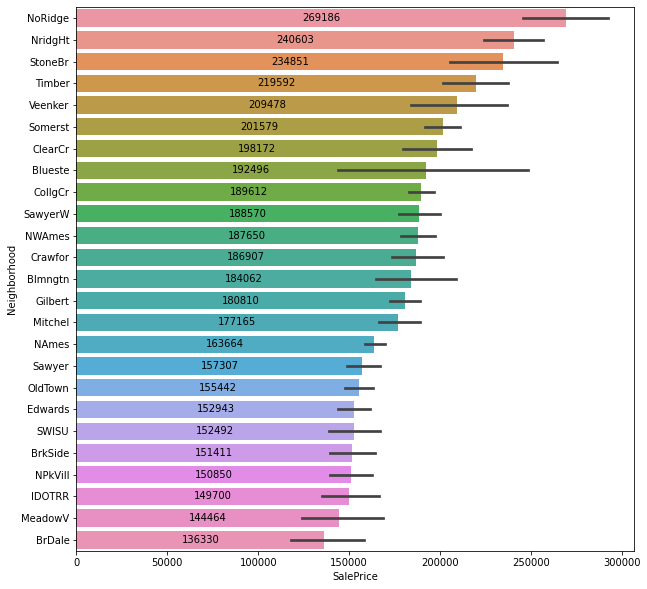

```python
df_sorted = new_house_df.groupby('Neighborhood')['SalePrice'].mean().sort_values(ascending=False)
plt.figure(figsize = (10,10))
ax = sns.barplot(data = new_house_df, y = 'Neighborhood', x = 'SalePrice', order = df_sorted.keys(), orient='h' )
mean = ax.bar_label(ax.containers[0], label_type='center')
```

### 2

5 neighborhoods with highest number of houses:

- step 1: group data by neighborhood.
- step 2: calculate the number of houses in each neighborhood using count().
- step 3: use nlargest(5) to find the answer.

5 neighborhoods with the most expensive houses.

- step 1: group data by neighborhood.
- step 2: calculate average house price in each group.
- step 3: sort values(by price) in descending order.

```python
max_house = new_house_df.groupby('Neighborhood')['Id'].count().nlargest(5)
print('Neighborhoods with the highest number of houses:')
print(max_house)
print('\n Neighborhoods with the most expensive houses: ')
print(df_sorted.head())
```

```
Neighborhoods with the highest number of houses:
Neighborhood
NAmes      443
CollgCr    267
OldTown    239
Edwards    192
Somerst    182
Name: Id, dtype: int64

 Neighborhoods with the most expensive houses:
Neighborhood
NoRidge    269185.573944
NridgHt    240602.656024
StoneBr    234851.215686
Timber     219592.283803
Veenker    209478.208333
Name: SalePrice, dtype: float64
```

### 3

Here, I use scatter plot to shows relationship between 2 variables. There is no correlation between bedrooms above the ground and the sale price. Hence, we can say that the number of bedrooms doesn’t affect the sale price.

I compute the correlation between these 2 variables to double check!

|  | BedroomAbvGr | SalePrice |
| --- | --- | --- |
| BedroomAbvGr | 1.000000 | 0.083414 |
| SalePrice | 0.083414 | 1.000000 |

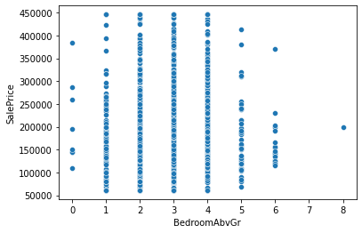

```python
sns.scatterplot(x = house_df['BedroomAbvGr'], y = new_house_df["SalePrice"])
new_house_df[['BedroomAbvGr', 'SalePrice']].corr()
```

### 4

As we can see in heatmap below GarageCars and GarageArea have the highest correlation (0.89)

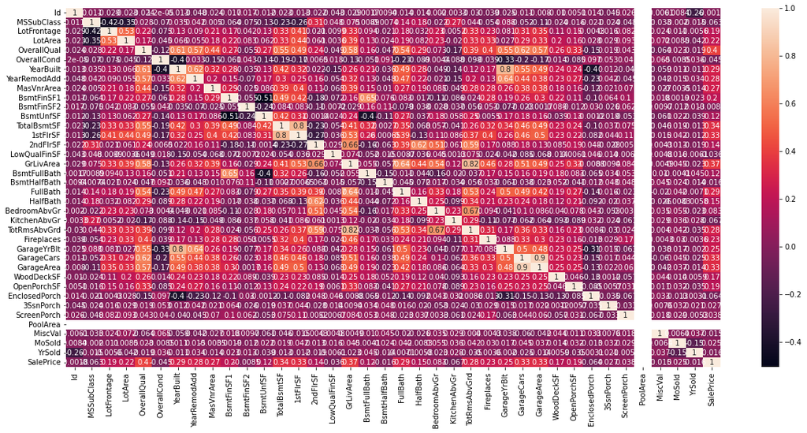

```python
plt.figure(figsize=(20,9))
corr1 = new_house_df.corr()
sns.heatmap(corr1 ,annot=True)
plt.show()
```

### 5

Histograms often tell more than boxplots. We can infer the approximate value of Q1, Q3, and median from histograms too.

But boxplots don't tell us anything about the distribution of data

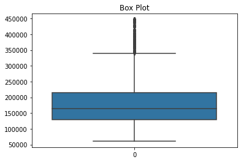

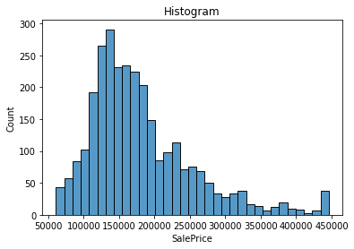

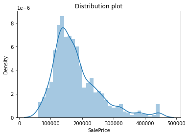

```python
sns.boxplot(new_house_df['SalePrice'])
plt.title('Box Plot')
plt.show()

sns.histplot(new_house_df['SalePrice'] , edgecolor='black')
plt.title('Histogram')
plt.show()

s = sns.distplot(new_house_df['SalePrice'])
plt.title('Distribution plot')
plt.show()
```

## 6

Scatter plot :

third categorical variable : can be encoded by modifying how the points are plotted. The most common encoding is through point color or shape.

third numerical variable : a common encoding is to change the point size(the bubble chart) Larger points indicate higher values. A continuous sequence of colors can also be used.For example, brighter colors indicate higher value.

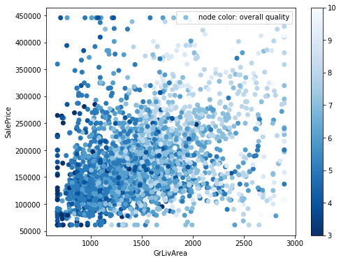

```python
x = new_house_df['GrLivArea']
y = new_house_df['SalePrice']
colors = new_house_df['OverallQual']

plt.figure(figsize=(8,6))
plt.scatter(x, y, c=colors , cmap='Blues_r',label = 'node color: overall quality')
plt.legend(loc = 'upper right')
plt.xlabel("GrLivArea")
plt.ylabel("SalePrice")
plt.colorbar()
plt.show()
```

# Purchase

```python
purchase_df = pd.read_csv(purchaseDatasetPath)
purchase_df
```

|  | user_id | SKU | AddedTime | Price | CurrencyISO |
| --- | --- | --- | --- | --- | --- |
| 0 | 6192636 | personal_offer_starter_pack | 2023-01-31 13:16:55.991756+00:00 | 2.29 | GBP |
| 1 | 5954105 | bundle_pack_1 | 2023-01-06 19:20:33.631714+00:00 | 1.79 | EUR |
| 2 | 5954105 | coin_pack_1 | 2023-01-07 15:56:47.792655+00:00 | 0.79 | EUR |
| 3 | 5903715 | bundle_pack_1 | 2023-01-01 18:48:38.391356+00:00 | 1.99 | USD |
| 4 | 5984323 | golden_ticket_season_pass | 2023-01-11 21:13:47.161073+00:00 | 9.99 | USD |
| ... | ... | ... | ... | ... | ... |
| 1408 | 5964679 | bundle_pack_1 | 2023-02-01 13:13:43.680081+00:00 | 1.49 | USD |
| 1409 | 5964679 | coin_pack_1 | 2023-01-19 13:51:50.503887+00:00 | 0.99 | USD |
| 1410 | 5964679 | bundle_pack_1 | 2023-02-04 23:15:25.865344+00:00 | 1.49 | USD |
| 1411 | 5964679 | coin_pack_1 | 2023-01-20 15:43:32.899227+00:00 | 0.99 | USD |
| 1412 | 4756103 | golden_ticket_season_pass | 2023-02-03 14:45:07.543052+00:00 | 9.99 | USD |

1413 rows × 5 columns

## 1 Currency Conversion

We need to find the conversion rate for each currency in dataframe. after that we divide price on the founded rate.

Finally, we have to set the value of CurrencyISO column to USD.

```python
url = 'https://v6.exchangerate-api.com/v6/ba2c95783ef45e7da2811f99/latest/USD'
response = requests.get(url)
data = response.json()

purchase_df["Price"] = purchase_df.apply(lambda x: x['Price'] / data['conversion_rates'][x['CurrencyISO']] , axis = 1)
purchase_df['CurrencyISO'] = "USD"
purchase_df
```

|  | user_id | SKU | AddedTime | Price | CurrencyISO |
| --- | --- | --- | --- | --- | --- |
| 0 | 6192636 | personal_offer_starter_pack | 2023-01-31 13:16:55.991756+00:00 | 2.783518 | USD |
| 1 | 5954105 | bundle_pack_1 | 2023-01-06 19:20:33.631714+00:00 | 1.919983 | USD |
| 2 | 5954105 | coin_pack_1 | 2023-01-07 15:56:47.792655+00:00 | 0.847367 | USD |
| 3 | 5903715 | bundle_pack_1 | 2023-01-01 18:48:38.391356+00:00 | 1.990000 | USD |
| 4 | 5984323 | golden_ticket_season_pass | 2023-01-11 21:13:47.161073+00:00 | 9.990000 | USD |
| ... | ... | ... | ... | ... | ... |
| 1408 | 5964679 | bundle_pack_1 | 2023-02-01 13:13:43.680081+00:00 | 1.490000 | USD |
| 1409 | 5964679 | coin_pack_1 | 2023-01-19 13:51:50.503887+00:00 | 0.990000 | USD |
| 1410 | 5964679 | bundle_pack_1 | 2023-02-04 23:15:25.865344+00:00 | 1.490000 | USD |
| 1411 | 5964679 | coin_pack_1 | 2023-01-20 15:43:32.899227+00:00 | 0.990000 | USD |
| 1412 | 4756103 | golden_ticket_season_pass | 2023-02-03 14:45:07.543052+00:00 | 9.990000 | USD |

1413 rows × 5 columns

## 2

We need to combine purchases with users.(like joining in SQL)

To achieve this, we use merge and we choose left join on user id to make sure that we don’t lose any data from purchases.

```python
user_df = pd.read_csv(usersDatasetPath)
result = purchase_df.merge(user_df, on='user_id', how='left')
result
```

|  | user_id | SKU | AddedTime | Price | CurrencyISO | registered_time | country_code |
| --- | --- | --- | --- | --- | --- | --- | --- |
| 0 | 6192636 | personal_offer_starter_pack | 2023-01-31 13:16:55.991756+00:00 | 2.783518 | USD | 2023-01-30 16:12:02.731706+01:00 | GB |
| 1 | 5954105 | bundle_pack_1 | 2023-01-06 19:20:33.631714+00:00 | 1.919983 | USD | 2023-01-05 20:33:54.584158+01:00 | BE |
| 2 | 5954105 | coin_pack_1 | 2023-01-07 15:56:47.792655+00:00 | 0.847367 | USD | 2023-01-05 20:33:54.584158+01:00 | BE |
| 3 | 5903715 | bundle_pack_1 | 2023-01-01 18:48:38.391356+00:00 | 1.990000 | USD | 2022-12-30 18:47:41.108888+01:00 | US |
| 4 | 5984323 | golden_ticket_season_pass | 2023-01-11 21:13:47.161073+00:00 | 9.990000 | USD | 2023-01-09 18:57:06.353154+01:00 | US |
| ... | ... | ... | ... | ... | ... | ... | ... |
| 1408 | 5964679 | bundle_pack_1 | 2023-02-01 13:13:43.680081+00:00 | 1.490000 | USD | 2023-01-07 00:50:45.364926+01:00 | US |
| 1409 | 5964679 | coin_pack_1 | 2023-01-19 13:51:50.503887+00:00 | 0.990000 | USD | 2023-01-07 00:50:45.364926+01:00 | US |
| 1410 | 5964679 | bundle_pack_1 | 2023-02-04 23:15:25.865344+00:00 | 1.490000 | USD | 2023-01-07 00:50:45.364926+01:00 | US |
| 1411 | 5964679 | coin_pack_1 | 2023-01-20 15:43:32.899227+00:00 | 0.990000 | USD | 2023-01-07 00:50:45.364926+01:00 | US |
| 1412 | 4756103 | golden_ticket_season_pass | 2023-02-03 14:45:07.543052+00:00 | 9.990000 | USD | 2022-08-04 20:39:55.038077+02:00 | US |

1413 rows × 7 columns

## 1

We group purchases data by their date and sort them(by date). Then in each group, we sum up the price to reach total purchase in each day.

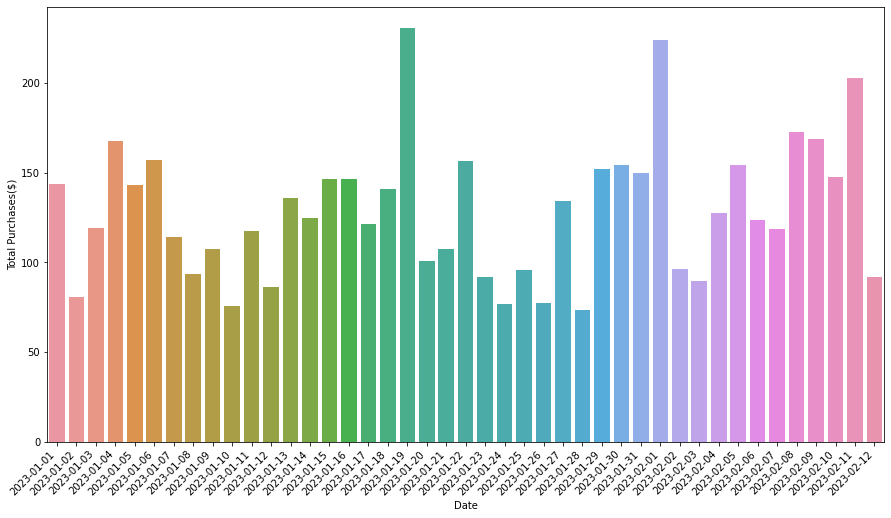

```python
purchase_copy = purchase_df.copy()
purchase_copy['AddedTime'] = pd.to_datetime(purchase_copy['AddedTime'])
sum_buys = purchase_copy.groupby(pd.Grouper(key ='AddedTime' , axis=0 , freq='D', sort=True))['Price'].sum()

fig, ax = plt.subplots(figsize = (15,8))
fig = sns.barplot(x = sum_buys.keys(), y = sum_buys.values, ax=ax)
ax.set(xlabel='Date', ylabel='Total Purchases($)')
x_dates = sum_buys.keys().date
plot = ax.set_xticklabels(labels=x_dates, rotation=45, ha='right')
```

## 2

We use nlargest to get 5 weeks with the highest total purchase.

```
2023-02-06 00:00:00+00:00 965.6622797978152
```

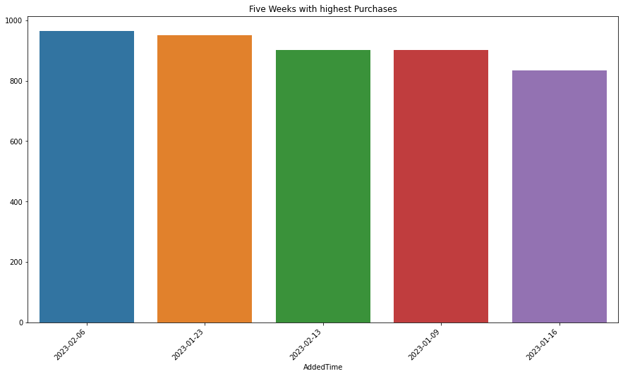

```python
weekly_buyings = purchase_copy.groupby(pd.Grouper(key ='AddedTime' , axis=0 , freq='W-MON')).sum()
five_weeks = weekly_buyings.nlargest(n = 5, columns = 'Price')['Price']
print(five_weeks.keys()[0] , five_weeks[0])

fig, ax = plt.subplots(figsize = (15,8))
fig = sns.barplot(x = five_weeks.keys(), y = five_weeks.values, ax=ax)
fig.set(title='Five Weeks with highest Purchases')
x_dates = five_weeks.keys().date
plot = ax.set_xticklabels(labels=x_dates, rotation=45, ha='right')
```

## 3

We can group data based on day of week! the process is pretty much like above, However, groups are integer and we need to map it to corresponded weekday.

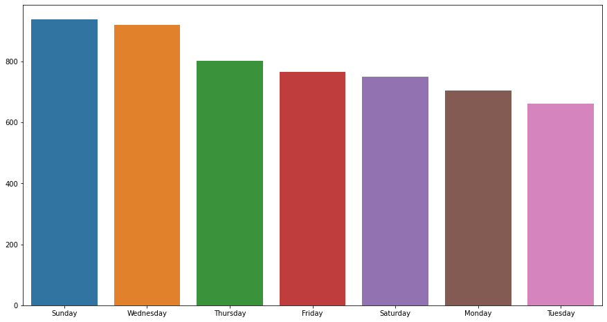

```python
days = ['Monday','Tuesday','Wednesday','Thursday','Friday','Saturday', 'Sunday']
weekdays = purchase_copy.groupby(purchase_copy['AddedTime'].dt.weekday).sum()['Price'].sort_values(ascending=False)
days = [days[i] for i in weekdays.keys()]
fig, ax = plt.subplots(figsize = (15,8))
fig = sns.barplot(x = days, y = weekdays.values, ax=ax)
```

## 4

We need to group by user_id to gather purchase records for each individual. We sum up prices to get the total purchases of each person.

```python
user = result.groupby('user_id')['Price'].sum().nlargest(n = 1)
user_id = user.keys()[0]
country = result.loc[result['user_id'] == user_id].head(n=1).country_code.values
print(f' id: {user_id} - country : {country[0]} - total purchase: {user.values[0]}')
```

```
 id: 2474953 - country : US - total purchase: 411.0
```

## 5

The only new thing here is nunique function which returns number of unique elements. The US has the most users.

```python
result.groupby('country_code').user_id.nunique()
```

```
country_code
AU     13
BE      4
CA     10
CH      1
DE     13
DK      3
ES      1
FR      3
GB     37
GR      1
HK      1
HR      1
ID      2
IL      1
IM      1
IT      1
JP      3
LK      1
MX      1
MY      1
NL      3
NO      1
PH      1
PL      4
RE      1
SE      2
SK      1
TW      1
US    191
ZA      1
Name: user_id, dtype: int64
```

## 6

```python
result.groupby('country_code')['Price'].sum().nlargest(5)
```

```
country_code
US    4226.720000
GB     381.852437
AU     250.133654
DE     208.417233
CA     129.652905
Name: Price, dtype: float64
```

## 7

We want to find a country with the highest average purchase price. First, we calculate total purchases of each person. Then compute the mean in each country.

```python
user_purchases = result.groupby(['country_code','user_id'], as_index=False).sum()
user_purchases.groupby('country_code')['Price'].mean().nlargest(1)
```

```
country_code
HK    33.84
Name: Price, dtype: float64
```

### 8

we compute number of registered users and the number of users who have bought something in each country.

```python
countries_users = user_df.groupby('country_code').count()['user_id']
countries_users
```

```
country_code
AD       1
AE     450
AF    4799
AG       1
AL      93
      ...
YE     156
YT       1
ZA     381
ZM      36
ZW      19
Name: user_id, Length: 201, dtype: int64
```

```python
active_users = result.groupby('country_code')['user_id'].count()
active_countries = active_users.keys()
confidence = active_users / countries_users[active_countries]
confidence.sort_values(ascending=False)
```

```
country_code
IM    1.000000
AU    0.357143
HK    0.200000
US    0.191419
CA    0.167920
BE    0.157233
GB    0.111570
RE    0.111111
DK    0.098592
NO    0.075000
PL    0.052257
SK    0.043478
JP    0.033898
DE    0.033597
IL    0.022989
FR    0.021106
SE    0.017391
HR    0.016129
MX    0.012407
GR    0.012245
CH    0.012195
TW    0.010309
NL    0.009346
LK    0.006536
ZA    0.005249
MY    0.004415
ES    0.003165
ID    0.002357
IT    0.001248
PH    0.000923
Name: user_id, dtype: float64
```

## 9

```python
from geopy.exc import GeocoderTimedOut
from geopy.geocoders import Nominatim

longitude = []
latitude = []

try:
    geolocator = Nominatim(user_agent="geo")

except GeocoderTimedOut:
    print('timeout')

def geolocate(country):
    try:
        loc = geolocator.geocode(country)
        latitude.append(loc.latitude)
        longitude.append(loc.longitude)
    except:
        latitude.append(np.nan)
        longitude.append(np.nan)
```

First, we need to find latitude and longitude for all countries. We have computed the number of users in countries and store it in countries_users

```python
countries_users = user_df.groupby('country_code' , as_index=False).count()[['country_code','user_id']]
countries_users
```

|  | country_code | user_id |
| --- | --- | --- |
| 0 | AD | 1 |
| 1 | AE | 450 |
| 2 | AF | 4799 |
| 3 | AG | 1 |
| 4 | AL | 93 |
| ... | ... | ... |
| 196 | YE | 156 |
| 197 | YT | 1 |
| 198 | ZA | 381 |
| 199 | ZM | 36 |
| 200 | ZW | 19 |

201 rows × 2 columns

```python
countries_users['country_code'].apply(geolocate)
countries_users["Longitude"] = longitude
countries_users["Latitude"] = latitude
```

Library below doesn't work with nan values. We had to drop a row.

```python
countries_users.dropna(subset = ['Latitude' , 'Longitude'], inplace = True)
countries_users[countries_users['country_code']== 'GE']
countries_users
```

|  | country_code | user_id | Longitude | Latitude |
| --- | --- | --- | --- | --- |
| 0 | AD | 1 | 1.573203 | 42.540717 |
| 1 | AE | 450 | 53.999483 | 24.000249 |
| 2 | AF | 4799 | 66.238514 | 33.768006 |
| 3 | AG | 1 | -61.955461 | 17.223472 |
| 4 | AL | 93 | -86.829534 | 33.258882 |
| ... | ... | ... | ... | ... |
| 196 | YE | 156 | 47.891527 | 16.347124 |
| 197 | YT | 1 | -136.002502 | 63.000147 |
| 198 | ZA | 381 | 24.991639 | -28.816624 |
| 199 | ZM | 36 | 27.558988 | -14.518912 |
| 200 | ZW | 19 | 29.746841 | -18.455496 |

200 rows × 4 columns

We can see the number of users in each region by clicking on blue circles.

```python
import folium
from folium.plugins import MarkerCluster

world_map = folium.Map(tiles="cartodbpositron",zoom_start= 15)
marker_cluster = MarkerCluster().add_to(world_map)

for i in range(len(countries_users)):

        lat = countries_users.iloc[i]['Latitude']
        long = countries_users.iloc[i]['Longitude']
        radius=5
        popup_text = """Country : {}<br>
                        Users : {}<br>"""
        popup_text = popup_text.format(countries_users.iloc[i]['country_code'],
                                  countries_users.iloc[i]['user_id']
                                   )

        folium.CircleMarker(location = [lat, long], radius=radius, popup= popup_text, fill =True).add_to(marker_cluster)
world_map
```

Make this Notebook Trusted to load map: File -> Trust Notebook

[interactive chart not shown]